# Full reference DNA pool analysis for primer set evaluation

This notebook begins with the dataframes that have been decontaminated using the site occupancy detection modeling (SODM) and dissimilarity approaches.

First, I will put together the taxonomy and feature tables, summarize the read counts per locus and per sample, and then begin exploring how many of the taxa that were added to the full reference DNA pool were identified and at which taxonomic level.

## Load data

```r
library(tidyverse)
library(stringi)
library(readxl)
library(vegan)
library(readr)
library(stringi)
library(textshape)
library(reshape2)


# un-collapsed and collapsed versions of the taxonomy with a 98% identity threshold for species-level ID
tax_df_clean_slim <- readRDS("../extdata/downsampled_loci/data/uncollapsed_taxonomy_spp_98.rds")
clean_taxonomy_df_unique <- readRDS("../extdata/downsampled_loci/data/unique_taxonomy_spp_98.rds")

# load decontaminated feature table
ref_sodm_bray_filtered_unique <- readRDS("../extdata/downsampled_loci/data/feature_table_sodm_bray_filtered.rds")
```

Read in the reference species for the full pool

```r
# list of species in the reference mock community
reference_spp <- readxl::read_xlsx("../data/full_reference_spp_database_info.xlsx") %>%
  select(2:4, 6:11)
```

```
* `` -> ...12
```

```r
reference_spp %>%
  select(species) %>%
  distinct()
```

| species |
| --- |
| Alopias_vulpinus |
| Alosa_pseudoharengus |
| Ammodytes_dubius |
| Anchoa_hepsetus |
| Anchoa_mitchilli |
| Antigonia_capros |
| Auxis_rochei |
| Bairdiella_chrysoura |
| Balistes_capriscus |
| Benthosema_pterotum |

[output cut: 93 more lines]

103 species 88 genera 60 families

## Feature table sequences - decontaminated

```r
# reads <- ref_sodm_bray_filtered_unique %>%
#   group_by(sample) %>%
#   summarise(sum(count)) %>%
#   arrange(desc(`sum(count)`)) %>%
#   ggplot(aes(x = reorder(sample, `sum(count)`), y = `sum(count)`)) +
#   geom_bar(stat = "identity") +
#   theme_minimal()
#
# reads + theme(
#   axis.text.x = element_text(angle = 90, hjust = 0.95)
# ) +
#   xlab("sample") +
#   ylab("total reads")
```

How many reads per locus?

[output not shown]

[output cut: 11 more lines]

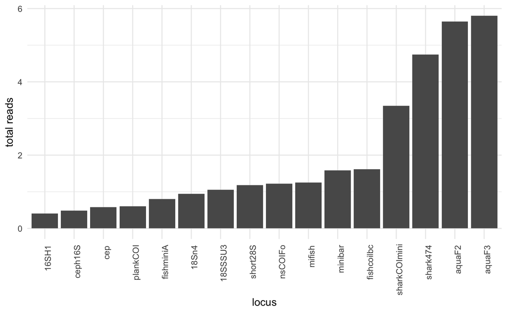

```r
loc.reads2 <- ref_sodm_bray_filtered_unique %>%
  filter(!locus %in% c("teleo", "crust2", "16Sfish", "16Svar", "crust16S", "L2513H2714")) %>%
  group_by(locus) %>%
  summarise(sum(count)) %>%
  arrange(desc(`sum(count)`)) %>%
  ggplot(aes(x = reorder(locus, `sum(count)`), y = (`sum(count)`)/1000000)) +
  geom_bar(stat = "identity") +
  theme_minimal()

loc.reads2 + theme(
  axis.text.x = element_text(angle = 90, hjust = 0.95)
) +
  xlab("locus") +
  ylab("total reads")
```

```r
NA
NA
```

Quantify some of that:

```r
# ref_sodm_bray_filtered_unique %>%
#   filter(str_detect(sample, "FRP")) %>%
#   group_by(locus) %>%
#   summarise(sum(count)) %>%
#   mutate(total_reads = sum(`sum(count)`)) %>%
#   mutate(prop = `sum(count)`/total_reads) %>%
#   mutate(mean = mean(`sum(count)`)) %>%
#   mutate(sd = sd(`sum(count)`)) %>%
#   mutate(median = median(`sum(count)`)) %>%
#   arrange(`sum(count)`) %>%
#   mutate(perc = mean*0.001) %>%
#   mutate(perc2 = mean*0.01)
#
```

top performing loci = what % of mean?

## Combine taxonomy and sample data frames

```r
# using the uncollapsed taxonomny data frame
features_taxa_df <- ref_sodm_bray_filtered_unique %>%
  left_join(., tax_df_clean_slim) %>%
  filter(!is.na(species)) # remove the sequence counts for things that are not matching taxonomy (at this point)
```

Lots of sequences eliminated at the taxonomy-binding stage… probably a fair number are bacterial since they are found in the extraction blanks, etc.

## Full reference DNA pool

To assess locus performance, select just the samples from the full-reference pool (FRP)

```r
ref_pool_df <- features_taxa_df %>%
  filter(stri_detect(sample, regex = "FRP")) # select just the full ref pool samples
```

Here I’m operating with the non-collapsed dataframe, which includes multiple top species hits for each sequence. Therefore, when I left-join those data to the reference species dataframe at the species-level, this allows for any of those top-taxonomic hits per sequence to match-up with the reference species.

```r
# count the number of reference species that are not identified to SPECIES by ANY of the loci
reference_spp %>%
  left_join(., ref_pool_df, by = c("species", "genus", "family")) %>%
  filter(is.na(locus)) # how many NAs?
```

| species | genus | family | Vouchered | COI | 12s | 16 | 18s | 28s | locus | seq | sample | count | order | class | phylum | domain | taxon_percID | taxonomic_level | taxon |
| --- | --- | --- | --- | --- | --- | --- | --- | --- | --- | --- | --- | --- | --- | --- | --- | --- | --- | --- | --- |
| Balistes_capriscus | Balistes | Balistidae | yes | 44 | 4 | 4 | 0 | 1 | NA | NA | NA | NA | NA | NA | NA | NA | NA | NA | NA |
| Decapterus_sp. | Decapterus | Carangidae | no | 78 | 5 | 3 | 0 | 0 | NA | NA | NA | NA | NA | NA | NA | NA | NA | NA | NA |
| Labeobarbus_sp. | Labeobarbus | Cyprinidae | no | 88 | 13 | 12 | 0 | 0 | NA | NA | NA | NA | NA | NA | NA | NA | NA | NA | NA |
| Loliolus_sp. | Loliolus | Loliginidae | no | 1309 | 45 | 567 | 98 | 44 | NA | NA | NA | NA | NA | NA | NA | NA | NA | NA | NA |
| Petrochromis_kazumbe | Petrochromis | Cichlidae | no | 0 | 0 | 0 | 0 | 0 | NA | NA | NA | NA | NA | NA | NA | NA | NA | NA | NA |
| Priacanthus_arenatus | Priacanthus | Priacanthidae | yes | 16 | 1 | 2 | 0 | 1 | NA | NA | NA | NA | NA | NA | NA | NA | NA | NA | NA |
| Sardinella_sp. | Sardinella | Clupeidae | no | 791 | 81 | 534 | 0 | 0 | NA | NA | NA | NA | NA | NA | NA | NA | NA | NA | NA |

```r
NA
```

A few things of note: We’re beginning to suspect there’s an ID issue with the sample that was supposed Synbranchus marmoratus. The Petrochromis species doesn’t have database info, so that could only be identified to genus. The Loliolus, Labeobarbus, Sardinella, and Decapterus sp. don’t have species info…

So that makes 2 species that we should get to species-level that we’re not identifying. 1. Balistes_capriscus 2. Priacanthus_arenatus

How many reference species that don’t have hits at the genus level?

```r
# count the number of reference species that are not identified to GENUS by ANY of the loci
reference_spp %>%
  left_join(., ref_pool_df, by = c("genus", "family")) %>%
  filter(is.na(locus)) # how many NAs?
```

| species.x | genus | family | Vouchered | COI | 12s | 16 | 18s | 28s | locus | seq | sample | count | species.y | order | class | phylum | domain | taxon_percID | taxonomic_level | taxon |
| --- | --- | --- | --- | --- | --- | --- | --- | --- | --- | --- | --- | --- | --- | --- | --- | --- | --- | --- | --- | --- |
| Balistes_capriscus | Balistes | Balistidae | yes | 44 | 4 | 4 | 0 | 1 | NA | NA | NA | NA | NA | NA | NA | NA | NA | NA | NA | NA |
| Priacanthus_arenatus | Priacanthus | Priacanthidae | yes | 16 | 1 | 2 | 0 | 1 | NA | NA | NA | NA | NA | NA | NA | NA | NA | NA | NA | NA |

```r
NA
```

Same two at the genus-level: 1. Balistes_capriscus 2. Priacanthus_arenatus

How many reference species don’t have hits at the family level?

```r
reference_spp %>%
  left_join(., ref_pool_df, by = "family") %>%
  filter(is.na(locus)) # how many NAs?
```

| species.x | genus.x | family | Vouchered | COI | 12s | 16 | 18s | 28s | locus | seq | sample | count | species.y | genus.y | order | class | phylum | domain | taxon_percID | taxonomic_level | taxon |
| --- | --- | --- | --- | --- | --- | --- | --- | --- | --- | --- | --- | --- | --- | --- | --- | --- | --- | --- | --- | --- | --- |

```r
NA
```

I’ll add a variable that designates the reference species as positive controls so then I can filter based on that.

```r
FRP <- reference_spp %>%
  mutate(control = "positive")

# these four taxa don't have species-level identities, so I'm not going to include them as part of the denominator for the % of species detected.
FRP %>%
  filter(str_detect(species, "_sp."))
```

| species | genus | family | Vouchered | COI | 12s | 16 | 18s | 28s | control |
| --- | --- | --- | --- | --- | --- | --- | --- | --- | --- |
| Decapterus_sp. | Decapterus | Carangidae | no | 78 | 5 | 3 | 0 | 0 | positive |
| Labeobarbus_sp. | Labeobarbus | Cyprinidae | no | 88 | 13 | 12 | 0 | 0 | positive |
| Loliolus_sp. | Loliolus | Loliginidae | no | 1309 | 45 | 567 | 98 | 44 | positive |
| Sardinella_sp. | Sardinella | Clupeidae | no | 791 | 81 | 534 | 0 | 0 | positive |

### Conditional join

Can I join the dataframe in a way that retains the species/genus/family information for whichever taxonomic level is appropriate?

```r
family_joined_df <- FRP %>%
  select(species, genus, family, control) %>%
  full_join(., ref_pool_df, by = "family") %>%
  unique()

# using the full-join, now I need to propagate the information for the species and genera that are in common
conditional_merged_df <- family_joined_df %>%
  mutate(species = ifelse(species.x == species.y, species.x, NA)) %>%
  mutate(genus = ifelse(genus.x == genus.y, genus.x, NA)) %>% # reorganize the dataframe
  rename(ref_species = species.x, ref_genus = genus.x) %>%
  select(ref_species, species, ref_genus, genus, family, control, locus, seq, sample, count, species.y, genus.y, order, class, phylum, domain, taxon_percID, taxonomic_level, taxon)

# take a look
conditional_merged_df %>% head()
```

| ref_species | species | ref_genus | genus | family | control | locus | seq | sample | count | species.y | genus.y | order | class | phylum | domain | taxon_percID | taxonomic_level | taxon |
| --- | --- | --- | --- | --- | --- | --- | --- | --- | --- | --- | --- | --- | --- | --- | --- | --- | --- | --- |
| Alopias_vulpinus | NA | Alopias | Alopias | Alopiidae | positive | 18SSSU3 | 1713c79fe52b4e431718c355350c5b72 | FRP_1_1 | 1016 | Alopias_pelagicus | Alopias | Lamniformes | Chondrichthyes | Chordata | Eukaryota | 99.415 | phylum | Chordata |
| Alopias_vulpinus | NA | Alopias | Alopias | Alopiidae | positive | 18SSSU3 | 72e90e524a760e824670235195cfa9a4 | FRP_1_1 | 215 | Alopias_pelagicus | Alopias | Lamniformes | Chondrichthyes | Chordata | Eukaryota | 99.415 | phylum | Chordata |
| Alopias_vulpinus | NA | Alopias | Alopias | Alopiidae | positive | 18SSSU3 | 52f810c328b4d83c45ada0ce7c4e9d36 | FRP_1_1 | 77 | Alopias_pelagicus | Alopias | Lamniformes | Chondrichthyes | Chordata | Eukaryota | 96.491 | phylum | Chordata |
| Alopias_vulpinus | NA | Alopias | Alopias | Alopiidae | positive | 18Sn4 | abae7cf84ce2b7148c507d679f85fa6f | FRP_1_1 | 1866 | Alopias_pelagicus | Alopias | Lamniformes | Chondrichthyes | Chordata | Eukaryota | 99.415 | phylum | Chordata |
| Alopias_vulpinus | NA | Alopias | Alopias | Alopiidae | positive | 18Sn4 | fdf82e386bf6f0d984ca5fe691e940d7 | FRP_1_1 | 230 | Alopias_pelagicus | Alopias | Lamniformes | Chondrichthyes | Chordata | Eukaryota | 99.419 | phylum | Chordata |
| Alopias_vulpinus | NA | Alopias | Alopias | Alopiidae | positive | 18Sn4 | f2e6972fc7942ce8211c6fba70a06664 | FRP_1_1 | 79 | Alopias_pelagicus | Alopias | Lamniformes | Chondrichthyes | Chordata | Eukaryota | 97.059 | phylum | Chordata |

```r
conditional_merged_df %>%
  filter(taxonomic_level == "species" & is.na(species))
```

| ref_species | species | ref_genus | genus | family | control | locus | seq | sample | count | species.y | genus.y | order | class | phylum | domain | taxon_percID | taxonomic_level | taxon |
| --- | --- | --- | --- | --- | --- | --- | --- | --- | --- | --- | --- | --- | --- | --- | --- | --- | --- | --- |
| Alosa_pseudoharengus | NA | Alosa | NA | Clupeidae | positive | aquaF2 | 7df71b28f349c3a22769286bb9e7fbb6 | FRP_1_1 | 405 | Brevoortia_tyrannus | Brevoortia | Clupeiformes | Actinopterygii | Chordata | Eukaryota | 99.457 | species | Brevoortia_tyrannus |
| Alosa_pseudoharengus | NA | Alosa | NA | Clupeidae | positive | aquaF3 | bd041249e371c1424709241c4de9256e | FRP_1_1 | 12296 | Brevoortia_tyrannus | Brevoortia | Clupeiformes | Actinopterygii | Chordata | Eukaryota | 99.363 | species | Brevoortia_tyrannus |
| Alosa_pseudoharengus | NA | Alosa | NA | Clupeidae | positive | mifish | 73f4c80cb0472c0cd5fe438696babc6e | FRP_1_1 | 3988 | Brevoortia_tyrannus | Brevoortia | Clupeiformes | Actinopterygii | Chordata | Eukaryota | 100.000 | species | Brevoortia_tyrannus |
| Alosa_pseudoharengus | NA | Alosa | NA | Clupeidae | positive | nsCOIFo | bc3be33d749a2e193ec229e92aa72486 | FRP_1_1 | 26 | Stolothrissa_tanganicae | Stolothrissa | Clupeiformes | Actinopterygii | Chordata | Eukaryota | 99.200 | species | Stolothrissa_tanganicae |
| Alosa_pseudoharengus | NA | Alosa | NA | Clupeidae | positive | nsCOIFo | 3d09fc4fdebea4a917a452ea06a9f3a6 | FRP_1_1 | 4 | Brevoortia_tyrannus | Brevoortia | Clupeiformes | Actinopterygii | Chordata | Eukaryota | 100.000 | species | Brevoortia_tyrannus |
| Alosa_pseudoharengus | NA | Alosa | NA | Clupeidae | positive | shark474 | bd041249e371c1424709241c4de9256e | FRP_1_1 | 5038 | Brevoortia_tyrannus | Brevoortia | Clupeiformes | Actinopterygii | Chordata | Eukaryota | 99.363 | species | Brevoortia_tyrannus |
| Alosa_pseudoharengus | NA | Alosa | NA | Clupeidae | positive | aquaF2 | 7df71b28f349c3a22769286bb9e7fbb6 | FRP_1_2 | 659 | Brevoortia_tyrannus | Brevoortia | Clupeiformes | Actinopterygii | Chordata | Eukaryota | 99.457 | species | Brevoortia_tyrannus |
| Alosa_pseudoharengus | NA | Alosa | NA | Clupeidae | positive | aquaF3 | bd041249e371c1424709241c4de9256e | FRP_1_2 | 11016 | Brevoortia_tyrannus | Brevoortia | Clupeiformes | Actinopterygii | Chordata | Eukaryota | 99.363 | species | Brevoortia_tyrannus |
| Alosa_pseudoharengus | NA | Alosa | NA | Clupeidae | positive | mifish | 73f4c80cb0472c0cd5fe438696babc6e | FRP_1_2 | 3791 | Brevoortia_tyrannus | Brevoortia | Clupeiformes | Actinopterygii | Chordata | Eukaryota | 100.000 | species | Brevoortia_tyrannus |
| Alosa_pseudoharengus | NA | Alosa | NA | Clupeidae | positive | nsCOIFo | bc3be33d749a2e193ec229e92aa72486 | FRP_1_2 | 50 | Stolothrissa_tanganicae | Stolothrissa | Clupeiformes | Actinopterygii | Chordata | Eukaryota | 99.200 | species | Stolothrissa_tanganicae |

[output cut: 990 more lines]

Use the conditionally-joined dataframe to count the number of reference species/genera/families identified by all loci.

```r
all.spp.level <- conditional_merged_df %>%
  filter(control == "positive") %>% # just the reference species (remove false positives)
  filter(taxonomic_level == "species") %>% # include hits to just species
  ungroup() %>%
  select(species) %>%
  filter(!is.na(species)) %>%
  distinct()

all.spp.level
```

| species |
| --- |
| Alopias_vulpinus |
| Anchoa_hepsetus |
| Antigonia_capros |
| Bairdiella_chrysoura |
| Benthosema_pterotum |
| Brevoortia_tyrannus |
| Carcharhinus_plumbeus |
| Centropristis_philadelphica |
| Chaetodipterus_faber |
| Citharichthys_arctifrons |

[output cut: 51 more lines]

```r
NA
```

Max number of species-level matches for all loci = 62 (61 for the downsampled dataset) There are the 41 reference species that were not identified to species. (which makes 42 not identified in the downsampled dataset.)

What about with just the four markers?

[output not shown]

[output cut: 51 more lines]